# Activity Monitoring

Rajat Sanadhya

# Background

Using devices such as Jawbone Up, Nike FuelBand, and Fitbit it is now possible to collect a large amount of data about personal activity relatively inexpensively. These type of devices are part of the quantified self movement – a group of enthusiasts who take measurements about themselves regularly to improve their health, to find patterns in their behavior, or because they are tech geeks. One thing that people regularly do is quantify how much of a particular activity they do, but they rarely quantify how well they do it. In this project, your goal will be to use data from accelerometers on the belt, forearm, arm, and dumbell of 6 participants. They were asked to perform barbell lifts correctly and incorrectly in 5 different ways. More information is available from the website here: http://web.archive.org/web/20161224072740/http:/groupware.les.inf.puc-rio.br/har (see the section on the Weight Lifting Exercise Dataset).

# Data

The **training data** for this project are available here: https://d396qusza40orc.cloudfront.net/predmachlearn/pml-training.csv  
The **test data** are available here: https://d396qusza40orc.cloudfront.net/predmachlearn/pml-testing.csv  
The data for this project come from this source: http://web.archive.org/web/20161224072740/http:/groupware.les.inf.puc-rio.br/har. If you use the document you create for this class for any purpose please cite them as they have been very generous in allowing their data to be used for this kind of assignment.

# Goal

The goal of your project is to predict the manner in which they did the exercise. This is the “classe” variable in the training set. You may use any of the other variables to predict with. You should create a report describing how you built your model, how you used cross validation, what you think the expected out of sample error is, and why you made the choices you did. You will also use your prediction model to predict 20 different test cases.

# Reproducibility

This markdown contains all the required necessary steps to make sure this code is reproducible. The code doesn’t require much external resources and relies mostly on pre-installed R packages. But you will need to install the packages listed below. These packages are only for the machine learning parts of the script.

```r
library(caret)
```

```r
library(rpart)
library(rpart.plot)
```

# Getting Data

Before strarting this, just place this file wherever you seems fit, this script will download and save the data on its own, **Just make sure you have a folde named “Data” in the directory you are running this scrip.** To know your current working directory can be found by calling the function `getwd()` in your R console.You can navigate to the desired directory, where the `Data` folder exists, using `setwd(dirPath)` function in R console.Here, `dirPath` is the path to the directory.

```r
if (!file.exists(file.path(getwd(),"Data/training.csv"))) {
  download.file("https://d396qusza40orc.cloudfront.net/predmachlearn/pml-training.csv", destfile = file.path(getwd(),"Data/training.csv"))
}
if (!file.exists(file.path(getwd(),"Data/testing.csv"))) {
  download.file("https://d396qusza40orc.cloudfront.net/predmachlearn/pml-testing.csv", destfile = file.path(getwd(),"Data/testing.csv"))
}
```

# Loading Data

Reading the downloaded data

```r
train <- read.csv("Data/training.csv")
test <- read.csv("Data/testing.csv")
cat("\nTrain Data Dimensions : ", dim(train))
```

```
##
## Train Data Dimensions :  19622 160
```

```r
cat("\nTest Data Dimensions : ", dim(test))
```

```
##
## Test Data Dimensions :  20 160
```

The **training data** contains `19622` observations and `160` variables. The **test data** contains `20` observations and `160` variables.

# Data Cleaning

```r
cols <- (colSums(is.na(train)) == 0)
train <- train[, cols]
test <- test[, cols]
rm(cols)
```

- Now we will remove variables that do not have accelerometer measurememnts.

```r
train <- train[, !grepl("^X|timestamp|user_name", names(train))]
test <- test[, !grepl("^X|timestamp|user_name", names(test))]
```

- Now we will remove all those variables that have almost do not have a variance. This indicates that they are almost constant throughout the dataset.

```r
cols_nzv <-nearZeroVar(train, saveMetrics = TRUE)$nzv
train <- train[, !cols_nzv]
test <- test[, !cols_nzv]
rm(cols_nzv)
```

Now that we have cleaned our data, let’s check the dimensions of our train and test datasets.

```r
cat("Train Data Dimensions : ", dim(train))
```

```
## Train Data Dimensions :  19622 54
```

```r
cat("\nTest Data Dimensions : ", dim(test))
```

```
##
## Test Data Dimensions :  20 54
```

# Splitting Data

Now we will break the `train` data into **training set** and **validation set**. Here I set the seed to `1407`, so you also get the same random values as me.

```r
set.seed(1407) # For reproducibile purpose
index_train <- createDataPartition(train$classe, p = 0.80, list = FALSE)
validation <- train[-index_train, ]
train <- train[index_train, ]
rm(index_train)
```

# Data Modelling

Now we will apply various models over our data to see which works best for us.

## Decision Trees

- We generate a predictive model using the *Decision Tree* algorithm. we will also preview the decision tree created.

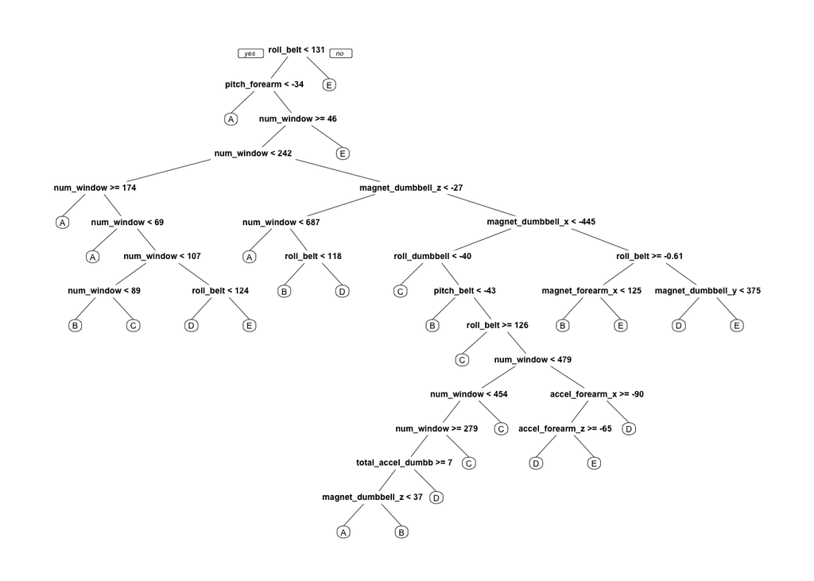

```r
modelTree <- rpart(classe ~ ., data = train, method = "class")
prp(modelTree)
```

Now lets see how this performs on our validation data.

```r
confusionMatrix(factor(validation$classe), predict(modelTree, validation, type = "class"))
```

```
## Confusion Matrix and Statistics
##
##           Reference
## Prediction   A   B   C   D   E
##          A 965  75   1  65  10
##          B  50 591  37  33  48
##          C   2  47 569  57   9
##          D  12  52  23 513  43
##          E   4  36   3  51 627
##
## Overall Statistics
##
##                Accuracy : 0.8323
##                  95% CI : (0.8202, 0.8438)
##     No Information Rate : 0.2633
##     P-Value [Acc > NIR] : < 2.2e-16
##
##                   Kappa : 0.7885
##
##  Mcnemar's Test P-Value : 5.139e-11
##
## Statistics by Class:
##
##                      Class: A Class: B Class: C Class: D Class: E
## Sensitivity            0.9342   0.7378   0.8989   0.7135   0.8507
## Specificity            0.9478   0.9462   0.9650   0.9594   0.9705
## Pos Pred Value         0.8647   0.7787   0.8319   0.7978   0.8696
## Neg Pred Value         0.9758   0.9336   0.9802   0.9372   0.9656
## Prevalence             0.2633   0.2042   0.1614   0.1833   0.1879
## Detection Rate         0.2460   0.1507   0.1450   0.1308   0.1598
## Detection Prevalence   0.2845   0.1935   0.1744   0.1639   0.1838
## Balanced Accuracy      0.9410   0.8420   0.9320   0.8365   0.9106
```

The Decision Tree model gives us an **Accuracy** of about `83.23%`.

## Random Forest

- We generate a predictive model using the *Random Forest* algorithm. Here we will use **4-fold cross validation** on the training data.

```r
model_rf <- train(classe ~ ., data = train, method = "rf", trControl = trainControl(method = "cv", 4), ntree = 200)
```

Now lets see how this performs on our validation data.

```r
confusionMatrix(factor(validation$classe), predict(model_rf, validation))
```

```
## Confusion Matrix and Statistics
##
##           Reference
## Prediction    A    B    C    D    E
##          A 1116    0    0    0    0
##          B    1  758    0    0    0
##          C    0    2  682    0    0
##          D    0    0    2  641    0
##          E    0    0    0    2  719
##
## Overall Statistics
##
##                Accuracy : 0.9982
##                  95% CI : (0.9963, 0.9993)
##     No Information Rate : 0.2847
##     P-Value [Acc > NIR] : < 2.2e-16
##
##                   Kappa : 0.9977
##
##  Mcnemar's Test P-Value : NA
##
## Statistics by Class:
##
##                      Class: A Class: B Class: C Class: D Class: E
## Sensitivity            0.9991   0.9974   0.9971   0.9969   1.0000
## Specificity            1.0000   0.9997   0.9994   0.9994   0.9994
## Pos Pred Value         1.0000   0.9987   0.9971   0.9969   0.9972
## Neg Pred Value         0.9996   0.9994   0.9994   0.9994   1.0000
## Prevalence             0.2847   0.1937   0.1744   0.1639   0.1833
## Detection Rate         0.2845   0.1932   0.1738   0.1634   0.1833
## Detection Prevalence   0.2845   0.1935   0.1744   0.1639   0.1838
## Balanced Accuracy      0.9996   0.9985   0.9982   0.9981   0.9997
```

Hence, we ca conclude that **Random Forest Model** gives us the better **Accuracy** among the two models.

# Predicting Test Data

Now we will apply the **Random Forest Model** to the `test` dataset.

```r
predict(model_rf, test[, -length(names(test))])
```

```
##  [1] B A B A A E D B A A B C B A E E A B B B
## Levels: A B C D E
```

# End-Note

In this document we create a model using the given data, I know this may not be the best model ever to be created for this problem, this is just small effort from my side. This problem can be further explored and various other models with different parameters can also be tried to improve the predictions.